# “Impacto de los habitos de vida en distintas enfermedades”

“Diana Arevalo Loaiza - Nicole Garcia Velasquez - Paula Rodriguez Sanabria”

2026-04-27

```r
library(RcmdrMisc)
```

## Objetivo general

Analizar y comparar distintas variables de habitos de vida tales como horas de sueño, dieta, si el paciente fuma o toma activamente, actividad fisica, nivel de estres, etc. Contra una gran variedad de enfermedades, demostrando que ciertos factores pueden o no pueden afectar directamente a la condicion medica que sufre cada paciente.

## Descripcion de las variables

EDAD: Edad del paciente en años (Cuantitativa discreta)

GENERO: Sexo del paciente (Cualitativa nominal)

CON_MED: Condición médica (Cualitativa nominal)

GLUCOSA: Nivel de glucosa en la sangre (Cuantitativa continua)

PRES_SAN: Medición de la presión sanguínea (Cuantitativa continua)

IMC: Índice de masa corporal (Cuantitativa continua)

SATU_OXI: Nivel de saturación de oxigeno en la sangre (Cuantitativa continua)

ESTANCIA: Días de hospitalización (Cuantitativa discreta)

COLESTEROL: Nivel de colesterol en la sangre (Cuantitativa continua)

TRIGLICERIDOS: Nivel de trigliceridos en la sangre (Cuantitativa continua)

HEMOGLOBINA: Hemoglobina glicosilada (Cuantitativa continua)

¿FUMA?: Estado de fumador (Cualitativa nominal dicotómica)

¿TOMA?: Consumo de alcohol (Cualitativa nominal dicotómica)

ACT_FISICA: Horas de actividad física por semana (Cuantitativa continua)

PUNT_ DIETA: Puntaje numérico de calidad de dieta (Cuantitativa continua)

HISTO_FAMI: Historial Familiar (Cualitativa nominal dicotómica)

NIVEL ESTRES: Nivel de estrés en escala numérica (Cuantitativa continua)

HORAS SUEÑO: Promedio de horas de sueño por día (Cuantitativa continua)

## Medidas de tendencia central de cada variable

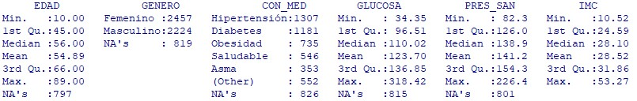

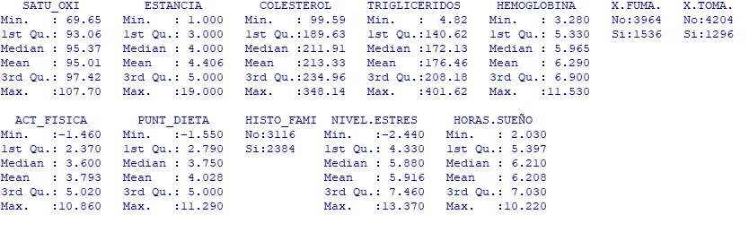

##Analisis de variables

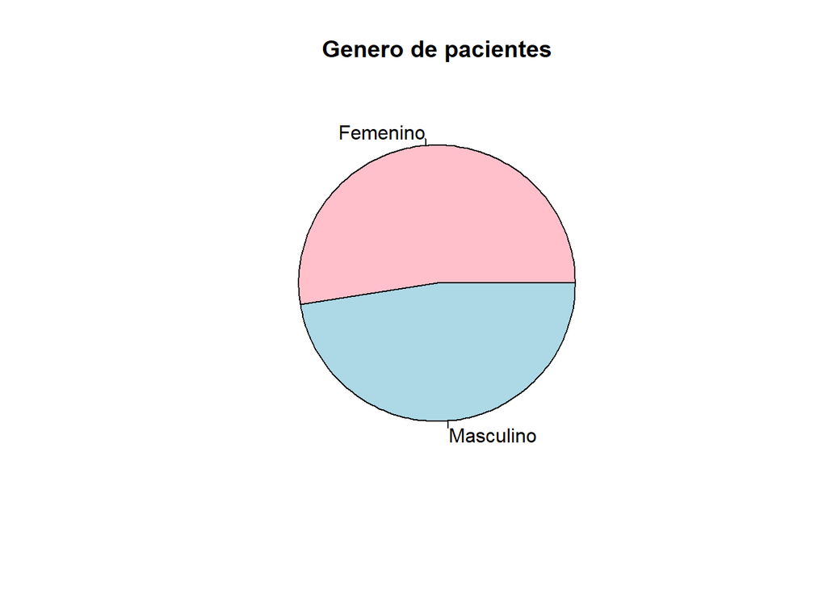

```r
conteo <- table(MED_DATA$GENERO)
pie(conteo, main = "Genero de pacientes" , col= c("pink", "lightblue"))
```

Con este diagrama circular evaluamos que los pacientes de la muestra son proporcionales y no hay alguna inclinacion hacia ningun genero.

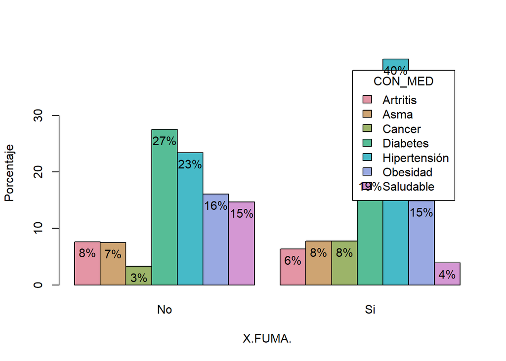

```r
with(MED_DATA, Barplot(MED_DATA$`¿FUMA?`, by=CON_MED, style="parallel", legend.pos="topright", xlab="X.FUMA.", ylab="Porcentaje",scale="percent", label.bars=TRUE))
```

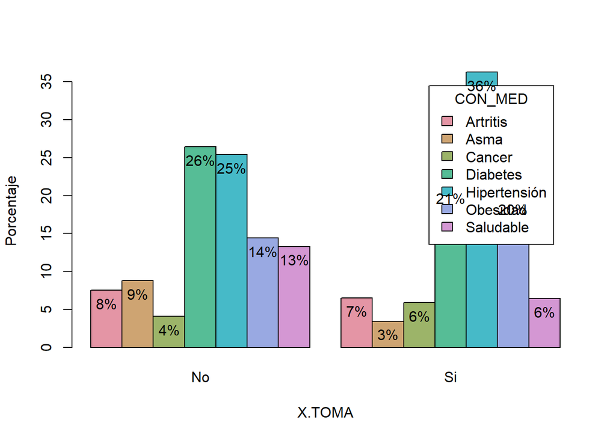

```r
with(MED_DATA, Barplot(MED_DATA$`¿TOMA?`, by=CON_MED, style="parallel", legend.pos="topright", xlab="X.TOMA", ylab="Porcentaje",scale="percent", label.bars=TRUE))
```

```r
library(rsconnect)
```